# Sequence Analysis

Jessica McCordic

09 September, 2026

# Sequence analysis

#### Borrowing heavily from this tutorial: https://quantdev.ssri.psu.edu/sites/qdev/files/sequence_tutorial_2017_1122.html

### Merge and reshape tables

For sequence analysis, we want (1) a wide df with one row per sequence ID with events (A/B) going across the columns and (2) a df with sequence ID and category (fishing/transit)

Sequence ID = each line & behavior combo Event = 2 states (A, B – alternating by selection) Class = 2 states (fishing, transit – determined during field trial)

```r
# first we need all the data together to map the categories onto the sub-selections

selns_data <- selns_int_og |>
  mutate(datetime = as_datetime(`Begin Date Time`),
         # assign alternating event codes
         event_ab = rep_len(c("a","b"), length.out = n()))

# pull behaviors & GPS from metrics_og
behav_gps <- metrics_og |>
  select(datetime,Line_num, activity,lat,lon, GPS_speed_kt, Dist_slant)

metrics_join <- all_metrics_og |>
  rename("datetime" = "RLDateTimeHyd") |>
  full_join(behav_gps, by = "datetime", keep = FALSE)


# map categories from metrics df onto selections
intervals_cat <- selns_data |>
  # join dfs together
  full_join(metrics_join) |>
  # get rid of some unused columns
  select(-c(View, Channel,`Low Freq (Hz)`, `High Freq (Hz)` ,`Begin Time (s)`, `End Time (s)`, `Begin Date Time`, OL_Hz:OL_16000, TOL_Hz, TOL_12500:TOL_20000))|>
  # sort by datetime
  arrange(datetime)|>

  # fill in data from metrics df into selection rows
  # fill selection number down to assign metrics rows to selections
  fill(c(Selection,event_ab, `Dur 90% (s)`,Line_num, activity,lat,lon, GPS_speed_kt, Dist_slant))|>
  # create sequence identifier of line + activity
  mutate(seq_ID = case_when(activity == "Off_eff_transit" ~ paste(Line_num, activity, sep = "_"),
                            grepl("dredge", activity)==TRUE ~ paste(Line_num, "fishing", sep = "_"),
                            TRUE ~ paste(Line_num, "transit", sep = "_"))) |>
  # filter to just get times included in selection table
  filter(seq_ID != "NA_transit")|>
  group_by(Selection) |>
  mutate(sel_dist = median(round(Dist_slant,0)),
         sel_dist_cat = case_when(round(sel_dist,0) <= 250 ~ "0-250m",
                                  round(sel_dist,0) > 250 & round(sel_dist,0) <=500 ~ "250-500m",
                                  round(sel_dist,0) > 500 & round(sel_dist,0) <=1000 ~ "500-1000m",
                                  round(sel_dist,0) > 1000 ~ ">1000m"))
# Assign sequence events based on relative SPL (high vs low) and Duration

# get 50th percentile to use as "short" vs "long" cutoff
dur_cut_val <- quantile(unique(intervals_cat$`Dur 90% (s)`))[3]

# start with intervals_cat
hilo_cat <- intervals_cat |>
  # group by seq_ID & selection to get median metrics per selection
  group_by(seq_ID, Selection) |>
  summarize(med_sel_BB = median(BB, na.rm = TRUE),
            med_sel_tol63 = median(TOL_63, na.rm = TRUE),
            med_sel_tol125 = median(TOL_125, na.rm = TRUE),
            med_sel_tol2k = median(TOL_2000, na.rm = TRUE),
            Dur_90_perc = mean(`Dur 90% (s)`)) |>

  # assign categories based on SPL metrics and duration
  mutate(
    n_selns = n(),

    ####
    # Broadband SPL
    # get lag and lead values for differences
    lag_BB = lag(med_sel_BB),
    lead_BB = lead(med_sel_BB),
    diff_BB = case_when(
      # if lagged value is NA (AKA first value in group), use lead value to fill it in
      is.na(lag_BB) ~ med_sel_BB - lead_BB,

      TRUE ~ med_sel_BB - lag_BB),
    # assign high/low categories based on TOL values per selection within each sequence
    BB_hilo = case_when(
      # For single instance of one selection for whole sequence (Sel 25, Line 4, transit),
      #   compare to previous selection (Sel 24) which is lower, so assign manually as "high"
      n_selns == 1 ~ "high",
      diff_BB > 0 ~ "high",
      diff_BB < 0 ~ "low"
    ),


    ####
    # TOL63
    # get lag and lead values for differences
    lag_tol63 = lag(med_sel_tol63),
    lead_tol63 = lead(med_sel_tol63),
    diff_tol63 = case_when(
      # if lagged value is NA (AKA first value in group), use lead value to fill it in
      is.na(lag_tol63) ~ med_sel_tol63 - lead_tol63,

      TRUE ~ med_sel_tol63 - lag_tol63),
    # assign high/low categories based on TOL values per selection within each sequence
    tol63_hilo = case_when(
      # For single instance of one selection for whole sequence (Sel 25, Line 4, transit),
      #   compare to previous selection (Sel 24) which is lower, so assign manually as "high"
      n_selns == 1 ~ "high",
      diff_tol63 > 0 ~ "high",
      diff_tol63 < 0 ~ "low"
    ),

    ####
    # TOL125
    # get lag and lead values for differences
    lag_tol125 = lag(med_sel_tol125),
    lead_tol125 = lead(med_sel_tol125),
    diff_tol125 = case_when(
      # if lagged value is NA (AKA first value in group), use lead value to fill it in
      is.na(lag_tol125) ~ med_sel_tol125 - lead_tol125,

      TRUE ~ med_sel_tol125 - lag_tol125),
    # assign high/low categories based on TOL values per selection within each sequence
    tol125_hilo = case_when(
      # For single instance of one selection for whole sequence (Sel 25, Line 4, transit),
      #   compare to previous selection (Sel 24) which is lower, so assign manually as "high"
      n_selns == 1 ~ "high",
      diff_tol125 > 0 ~ "high",
      diff_tol125 < 0 ~ "low"
    ),


    # TOL2000
    # get lag and lead values for differences
    lag_tol2k = lag(med_sel_tol2k),
    lead_tol2k = lead(med_sel_tol2k),
    diff_tol2k = case_when(
      # if lagged value is NA (AKA first value in group), use lead value to fill it in
      is.na(lag_tol2k) ~ med_sel_tol2k - lead_tol2k,

      TRUE ~ med_sel_tol2k - lag_tol2k),
    # assign high/low categories based on TOL values per selection within each sequence
    tol2k_hilo = case_when(
      # For single instance of one selection for whole sequence (Sel 25, Line 4, transit),
      #   compare to previous selection (Sel 24) which is lower, so assign manually as "high"
      n_selns == 1 ~ "high",
      diff_tol2k > 0 ~ "high",
      diff_tol2k < 0 ~ "low"
    ),

    # assign long/short categories based on 90% duration per selection within each sequence
    dur_long_short = case_when(
      Dur_90_perc <= dur_cut_val ~ "short",
      Dur_90_perc > dur_cut_val ~ "long"
    ),

    # paste SPL and duration combos together (4 possible values)
    event_hilo_tol63 = paste0(tol63_hilo, "_", dur_long_short),
    event_hilo_tol125 = paste0(tol125_hilo, "_", dur_long_short),
    event_hilo_tol2k = paste0(tol2k_hilo, "_", dur_long_short),
    event_hilo_BB = paste0(BB_hilo, "_", dur_long_short))
```

```
## `summarise()` has regrouped the output.
## ℹ Summaries were computed grouped by seq_ID and Selection.
## ℹ Output is grouped by seq_ID.
## ℹ Use `summarise(.groups = "drop_last")` to silence this message.
## ℹ Use `summarise(.by = c(seq_ID, Selection))` for per-operation grouping
##   (`?dplyr::dplyr_by`) instead.
```

```r
#### BB SPL
# set up df for sequence analysis
selns_seq_BB <- hilo_cat |>
  # filter out off effort for now
  filter(seq_ID != "Off_eff_transit") |>
  ungroup()|>
  group_by(seq_ID) |>
  # only keep columns needed for sequence analysis
  select(seq_ID,
         event_hilo_BB) |>
 # create time index variable per sequence
  mutate(time_idx = seq(1:n()))

#### TOL63
# set up df for sequence analysis
selns_seq_tol63 <- hilo_cat |>
  # filter out off effort for now
  filter(seq_ID != "Off_eff_transit") |>
  ungroup()|>
  group_by(seq_ID) |>
  # only keep columns needed for sequence analysis
  select(seq_ID,
         event_hilo_tol63) |>
 # create time index variable per sequence
  mutate(time_idx = seq(1:n()))


#### TOL125
# set up df for sequence analysis
selns_seq_tol125 <- hilo_cat |>
  # filter out off effort for now
  filter(seq_ID != "Off_eff_transit") |>
  ungroup()|>
  group_by(seq_ID) |>
  # only keep columns needed for sequence analysis
  select(seq_ID,
         event_hilo_tol125) |>
 # create time index variable per sequence
  mutate(time_idx = seq(1:n()))


#### TOL2000
# set up df for sequence analysis
selns_seq_tol2k <- hilo_cat |>
  # filter out off effort for now
  filter(seq_ID != "Off_eff_transit") |>
  ungroup()|>
  group_by(seq_ID) |>
  # only keep columns needed for sequence analysis
  select(seq_ID,
         event_hilo_tol2k) |>
 # create time index variable per sequence
  mutate(time_idx = seq(1:n()))




# create key for sequence IDs to fishing vs. transit
fish_states <- selns_seq_BB |>
  select(seq_ID) |>
  mutate(fish_state = case_when(grepl("fishing", seq_ID)==TRUE ~ "fishing",
                   TRUE ~ "transit"))
```

### Descriptives

How many sequences? How many events per sequence? How many events of each type across the dataset?

```r
length(unique(selns_seq_BB$seq_ID))
```

```
## [1] 18
```

```r
length(unique(fish_states$seq_ID))
```

```
## [1] 18
```

```r
# descriptives for N events per sequence (same for all metrics)
event_summ <- selns_seq_BB |>
  group_by(seq_ID) |>
  summarize(n_events = n()) |>
  summarize(mean_n = mean(n_events),
            med_n = median(n_events),
            min_n = min(n_events),
            max_n = max(n_events))
event_summ
```

```
## # A tibble: 1 × 4
##   mean_n med_n min_n max_n
##    <dbl> <dbl> <int> <int>
## 1   5.11   3.5     1    14
```

```r
#### BB SPL
behav_table_BB <- table(selns_seq_BB$event_hilo_BB)

behav_table_BB
```

```
##
##  high_long high_short   low_long  low_short
##         29         23         22         18
```

```r
#### TOL63

behav_table_tol63 <- table(selns_seq_tol63$event_hilo_tol63)

behav_table_tol63
```

```
##
##  high_long high_short   low_long  low_short
##         30         20         21         21
```

```r
#### TOL125

behav_table_tol125 <- table(selns_seq_tol125$event_hilo_tol125)

behav_table_tol125
```

```
##
##  high_long high_short   low_long  low_short
##         22         24         29         17
```

```r
#### TOL2000

behav_table_tol2k <- table(selns_seq_tol2k$event_hilo_tol2k)

behav_table_tol2k
```

```
##
##  high_long high_short   low_long  low_short
##         27         21         24         20
```

### Creating sequences

```r
# reformat from long to wide

#### BB SPL
selns_seq_wide_BB <- selns_seq_BB |>
  filter(seq_ID != "pre_survey_Off_eff_transit",
         seq_ID != "post_survey_Off_eff_transit") |>
  pivot_wider(names_from = time_idx,
              values_from = event_hilo_BB)


#### TOL63
selns_seq_wide_tol63 <- selns_seq_tol63 |>
  filter(seq_ID != "pre_survey_Off_eff_transit",
         seq_ID != "post_survey_Off_eff_transit") |>
  pivot_wider(names_from = time_idx,
              values_from = event_hilo_tol63)

#### TOL125
selns_seq_wide_tol125 <- selns_seq_tol125 |>
  filter(seq_ID != "pre_survey_Off_eff_transit",
         seq_ID != "post_survey_Off_eff_transit") |>
  pivot_wider(names_from = time_idx,
              values_from = event_hilo_tol125)

#### TOL2000
selns_seq_wide_tol2k <- selns_seq_tol2k |>
  filter(seq_ID != "pre_survey_Off_eff_transit",
         seq_ID != "post_survey_Off_eff_transit") |>
  pivot_wider(names_from = time_idx,
              values_from = event_hilo_tol2k)
```

Create alphabet and assign labels

```r
# same for all metrics

# this contains categories that appear in the dataset
event_alphabet <- c("low_long",  "high_long", "low_short",  "high_short")

# formally assigning labels which might be helpful later
event_labels <- c("low_long",  "high_long", "low_short",  "high_short")

# assign colors (this feels unnecessary but sure)
event_colors <- viridis::plasma(n = 4, begin = 0.25, end = 0.75)
```

Create sequence object

```r
# define sequence using seqdef from TraMineR package
event_seq_BB <- seqdef(selns_seq_wide_BB,
                    var = 2:15,
                    alphabet = event_alphabet,
                    labels = event_labels,
                    xtstep = 2,
                    cpal = event_colors)
```

```
##  [>] found missing values ('NA') in sequence data
```

```
##  [>] preparing 16 sequences
```

```
##  [>] coding void elements with '%' and missing values with '*'
```

```
##  [>] 4 distinct states appear in the data:
```

```
##      1 = high_long
```

```
##      2 = high_short
```

```
##      3 = low_long
```

```
##      4 = low_short
```

```
##  [>] state coding:
```

```
##        [alphabet]  [label]    [long label]
```

```
##      1  low_long    low_long   low_long
```

```
##      2  high_long   high_long  high_long
```

```
##      3  low_short   low_short  low_short
```

```
##      4  high_short  high_short high_short
```

```
##  [>] 16 sequences in the data set
```

```
##  [>] min/max sequence length: 1/14
```

```r
event_seq_tol63 <- seqdef(selns_seq_wide_tol63,
                    var = 2:15,
                    alphabet = event_alphabet,
                    labels = event_labels,
                    xtstep = 2,
                    cpal = event_colors)
```

```
##  [>] found missing values ('NA') in sequence data
```

```
##  [>] preparing 16 sequences
```

```
##  [>] coding void elements with '%' and missing values with '*'
```

```
##  [>] 4 distinct states appear in the data:
```

```
##      1 = high_long
```

```
##      2 = high_short
```

```
##      3 = low_long
```

```
##      4 = low_short
```

```
##  [>] state coding:
```

```
##        [alphabet]  [label]    [long label]
```

```
##      1  low_long    low_long   low_long
```

```
##      2  high_long   high_long  high_long
```

```
##      3  low_short   low_short  low_short
```

```
##      4  high_short  high_short high_short
```

```
##  [>] 16 sequences in the data set
```

```
##  [>] min/max sequence length: 1/14
```

```r
event_seq_tol125 <- seqdef(selns_seq_wide_tol125,
                    var = 2:15,
                    alphabet = event_alphabet,
                    labels = event_labels,
                    xtstep = 2,
                    cpal = event_colors)
```

```
##  [>] found missing values ('NA') in sequence data
```

```
##  [>] preparing 16 sequences
```

```
##  [>] coding void elements with '%' and missing values with '*'
```

```
##  [>] 4 distinct states appear in the data:
```

```
##      1 = high_long
```

```
##      2 = high_short
```

```
##      3 = low_long
```

```
##      4 = low_short
```

```
##  [>] state coding:
```

```
##        [alphabet]  [label]    [long label]
```

```
##      1  low_long    low_long   low_long
```

```
##      2  high_long   high_long  high_long
```

```
##      3  low_short   low_short  low_short
```

```
##      4  high_short  high_short high_short
```

```
##  [>] 16 sequences in the data set
```

```
##  [>] min/max sequence length: 1/14
```

```r
event_seq_tol2k <- seqdef(selns_seq_wide_tol2k,
                    var = 2:15,
                    alphabet = event_alphabet,
                    labels = event_labels,
                    xtstep = 2,
                    cpal = event_colors)
```

```
##  [>] found missing values ('NA') in sequence data
```

```
##  [>] preparing 16 sequences
```

```
##  [>] coding void elements with '%' and missing values with '*'
```

```
##  [>] 4 distinct states appear in the data:
```

```
##      1 = high_long
```

```
##      2 = high_short
```

```
##      3 = low_long
```

```
##      4 = low_short
```

```
##  [>] state coding:
```

```
##        [alphabet]  [label]    [long label]
```

```
##      1  low_long    low_long   low_long
```

```
##      2  high_long   high_long  high_long
```

```
##      3  low_short   low_short  low_short
```

```
##      4  high_short  high_short high_short
```

```
##  [>] 16 sequences in the data set
```

```
##  [>] min/max sequence length: 1/14
```

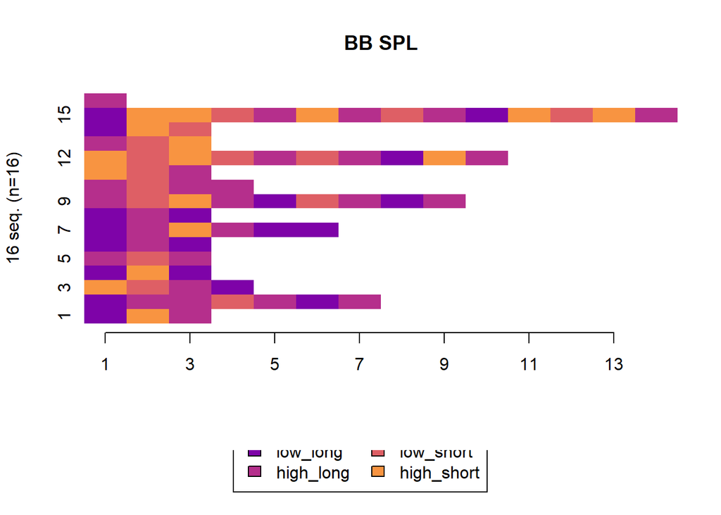

```r
# plot sequences

seqIplot(event_seq_BB, main = "BB SPL")
```

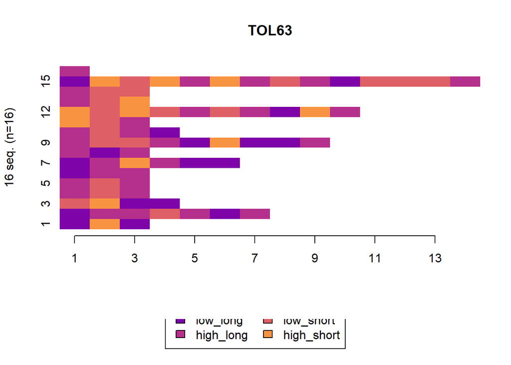

```r
seqIplot(event_seq_tol63, main = "TOL63")
```

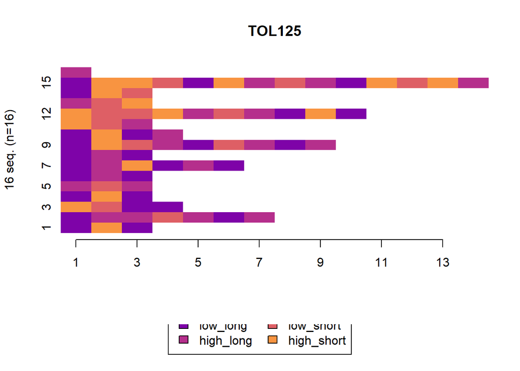

```r
seqIplot(event_seq_tol125, main = "TOL125")
```

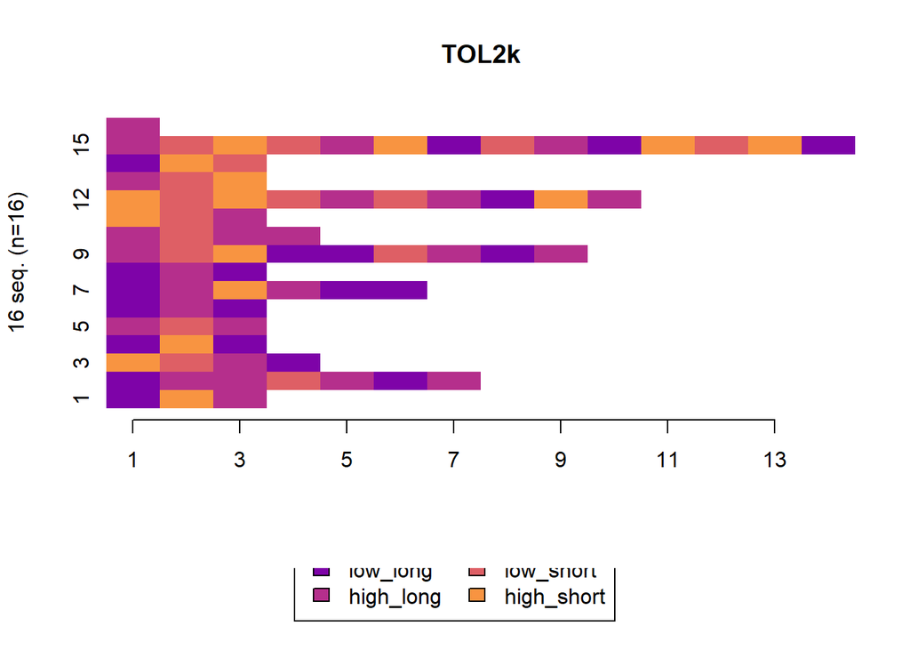

```r
seqIplot(event_seq_tol2k, main = "TOL2k")
```

Cost matrix

- Use standard cost matrix values: insertion/deletion cost = 1.0 missingness cost = 0.5*[highest cost in matrix] substitution cost = constant

```r
# same for all metrics
costmatrix <- seqsubm(event_seq_BB,
                      method="CONSTANT",
                      cval = 2,
                      with.missing=FALSE,
                      miss.cost=1,
                      time.varying=FALSE,
                      weighted=TRUE,
                      transition="both",
                      lag=1)
```

```
##  [>] creating 4x4 substitution-cost matrix using 2 as constant value
```

```r
costmatrix
```

```
##            low_long high_long low_short high_short
## low_long          0         2         2          2
## high_long         2         0         2          2
## low_short         2         2         0          2
## high_short        2         2         2          0
```

```r
# optimal matching dissimilarity matrix

dist_om_BB <- seqdist(event_seq_BB,
                   method = "OM",
                   indel = 1.0, # insertion/deletion cost = 1
                   sm = costmatrix, # sub matrix = cost matrix
                   with.missing = FALSE)
```

```
##  [>] 16 sequences with 4 distinct states
```

```
##  [>] checking 'sm' (size and triangle inequality)
```

```
##  [>] 15 distinct  sequences
```

```
##  [>] min/max sequence lengths: 1/14
```

```
##  [>] computing distances using the OM metric
```

```
##  [>] elapsed time: 0.02 secs
```

```r
dist_om_tol63 <- seqdist(event_seq_tol63,
                   method = "OM",
                   indel = 1.0, # insertion/deletion cost = 1
                   sm = costmatrix, # sub matrix = cost matrix
                   with.missing = FALSE)
```

```
##  [>] 16 sequences with 4 distinct states
```

```
##  [>] checking 'sm' (size and triangle inequality)
```

```
##  [>] 15 distinct  sequences
```

```
##  [>] min/max sequence lengths: 1/14
```

```
##  [>] computing distances using the OM metric
```

```
##  [>] elapsed time: 0.02 secs
```

```r
dist_om_tol125 <- seqdist(event_seq_tol125,
                   method = "OM",
                   indel = 1.0, # insertion/deletion cost = 1
                   sm = costmatrix, # sub matrix = cost matrix
                   with.missing = FALSE)
```

```
##  [>] 16 sequences with 4 distinct states
```

```
##  [>] checking 'sm' (size and triangle inequality)
```

```
##  [>] 14 distinct  sequences
```

```
##  [>] min/max sequence lengths: 1/14
```

```
##  [>] computing distances using the OM metric
```

```
##  [>] elapsed time: 0.01 secs
```

```r
dist_om_tol2k <- seqdist(event_seq_tol2k,
                   method = "OM",
                   indel = 1.0, # insertion/deletion cost = 1
                   sm = costmatrix, # sub matrix = cost matrix
                   with.missing = FALSE)
```

```
##  [>] 16 sequences with 4 distinct states
```

```
##  [>] checking 'sm' (size and triangle inequality)
```

```
##  [>] 15 distinct  sequences
```

```
##  [>] min/max sequence lengths: 1/14
```

```
##  [>] computing distances using the OM metric
```

```
##  [>] elapsed time: 0 secs
```

### Clustering

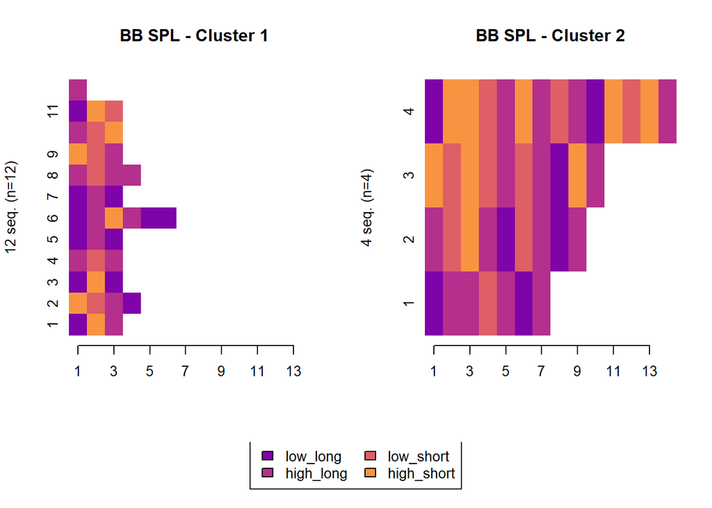

```r
####
# BB SPL
event_clusters_BB <- agnes(dist_om_BB, diss = TRUE, method = "ward")
# cut into 2 clusters
event_clust_BB_cut <- cutree(event_clusters_BB, k = 2) |>
  factor(labels = paste("Cluster", 1:2))

####
# TOL63
event_clusters_tol63 <- agnes(dist_om_tol63, diss = TRUE, method = "ward")
# cut into 2 clusters
event_clust_tol63_cut <- cutree(event_clusters_tol63, k = 2) |>
  factor(labels = paste("Cluster", 1:2))


####
# TOL125
event_clusters_tol125 <- agnes(dist_om_tol125, diss = TRUE, method = "ward")
# cut into 2 clusters
event_clust_tol125_cut <- cutree(event_clusters_tol125, k = 2) |>
  factor(labels = paste("Cluster", 1:2))


####
# TOL2000
event_clusters_tol2k <- agnes(dist_om_tol2k, diss = TRUE, method = "ward")
# cut into 2 clusters
event_clust_tol2k_cut <- cutree(event_clusters_tol2k, k = 2) |>
  factor(labels = paste("Cluster", 1:2))

# plot sequences
seqplot(event_seq_BB, group = event_clust_BB_cut, type = "I", main = "BB SPL")
```

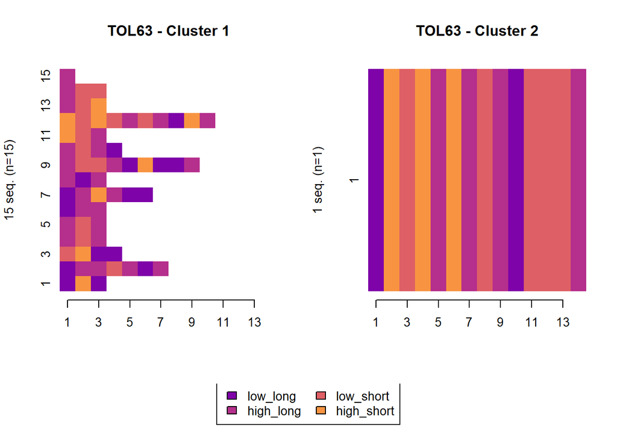

```r
seqplot(event_seq_tol63, group = event_clust_tol63_cut, type = "I", main = "TOL63")
```

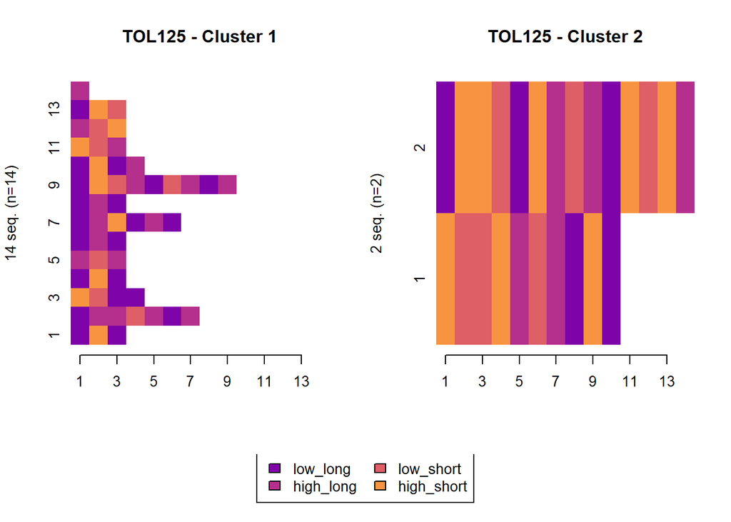

```r
seqplot(event_seq_tol125, group = event_clust_tol125_cut, type = "I", main = "TOL125")
```

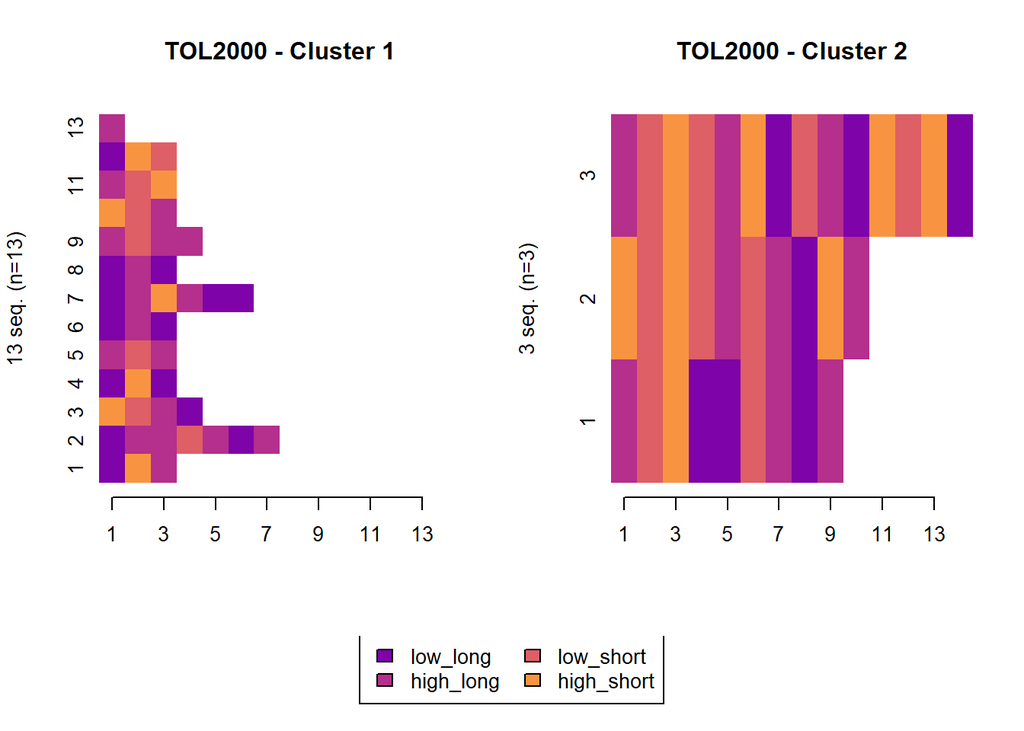

```r
seqplot(event_seq_tol2k, group = event_clust_tol2k_cut, type = "I", main = "TOL2000")
```

### Group differences between clusters

```r
# Test cluster stability with bootstrapping

cluster_boot_BB <- clusterboot(dist_om_BB,
            clustermethod = hclustCBI,
            method = "ward.D2",
            k = 2,
            seed = 13958)
```

[output not shown]

[output cut: 45 more lines]

[output not shown]

```r
# get Jaccard coefficient for each cluster
# hoping for > 0.85 = 'highly stable' or at least > 0.6 = 'likely to reflect a pattern'
cluster_boot_BB$bootmean
```

```
## [1] 0.9326580 0.7456667
```

```r
cluster_boot_BB$bootbrd
```

```
## [1]  0 31
```

```r
cluster_boot_tol63 <- clusterboot(dist_om_tol63,
            clustermethod = hclustCBI,
            method = "ward.D2",
            k = 2,
            seed = 13958)
```

[output not shown]

[output cut: 45 more lines]

[output not shown]

```r
# get Jaccard coefficient for each cluster
# hoping for > 0.85 = 'highly stable' or at least > 0.6 = 'likely to reflect a pattern'
cluster_boot_tol63$bootmean
```

```
## [1] 0.9185837 0.7503333
```

```r
cluster_boot_tol63$bootbrd
```

```
## [1]  2 30
```

```r
cluster_boot_tol125 <- clusterboot(dist_om_tol125,
            clustermethod = hclustCBI,
            method = "ward.D2",
            k = 2,
            seed = 13958)
```

[output not shown]

[output cut: 45 more lines]

[output not shown]

```r
# get Jaccard coefficient for each cluster
# hoping for > 0.85 = 'highly stable' or at least > 0.6 = 'likely to reflect a pattern'
cluster_boot_tol125$bootmean
```

```
## [1] 0.9525765 0.7816667
```

```r
cluster_boot_tol125$bootbrd
```

```
## [1]  0 28
```

```r
cluster_boot_tol2k <- clusterboot(dist_om_tol2k,
            clustermethod = hclustCBI,
            method = "ward.D2",
            k = 2,
            seed = 13958)
```

[output not shown]

[output cut: 45 more lines]

[output not shown]

```r
# get Jaccard coefficient for each cluster
# hoping for > 0.85 = 'highly stable' or at least > 0.6 = 'likely to reflect a pattern'
cluster_boot_tol2k$bootmean
```

```
## [1] 0.8900812 0.6881667
```

```r
cluster_boot_tol2k$bootbrd
```

```
## [1]  1 38
```

# Dendrograms and stats

## Broadband SPL

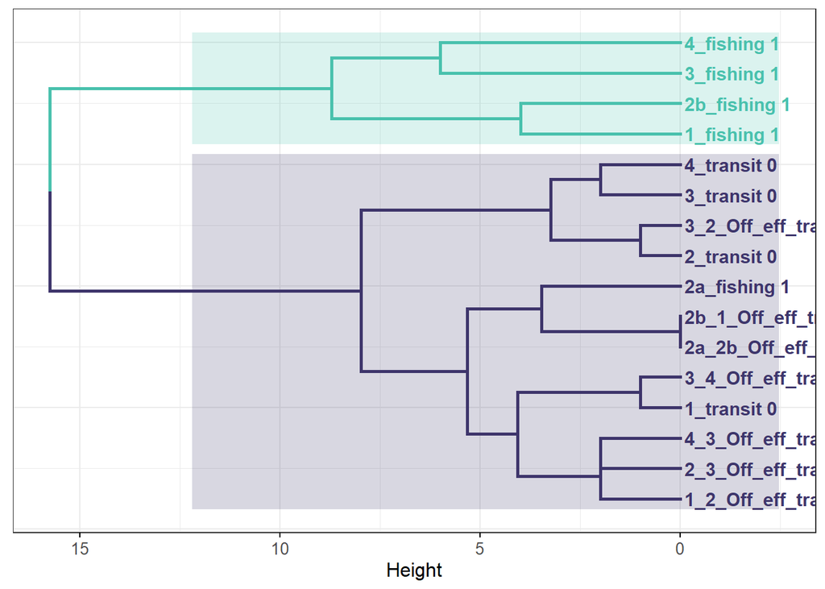

```r
# does vessel behavior differ by cluster membership?
# cluster ID = predictor
# vessel behav = response, coded as 1/0 (fishing/transit)

# add cluster labels to seq ID to associate w/fishing vs. transit
seq_clust_lab_BB <- selns_seq_wide_BB |>
  select(seq_ID) |>
  add_column(clust_ID = event_clust_BB_cut)|>
  mutate(fish_state_binom = case_when(grepl("fishing", seq_ID)==TRUE ~ 1,
                   TRUE ~ 0),
         leaf_label = paste(seq_ID, fish_state_binom))

event_clusters_BB$order.lab <- seq_clust_lab_BB$leaf_label[event_clusters_BB$order]
clust_colors = viridis::mako(n = 2, begin = 0.25, end = 0.75)

fviz_dend(event_clusters_BB,
          k = 2,
          color_labels_by_k = TRUE,
          k_colors = clust_colors,
          labels_font = "bold",

          rect = TRUE,
          rect_border = clust_colors,
          rect_fill = TRUE,

          lwd=1,
          horiz = TRUE,
          ggtheme = theme_bw()) +
  theme(axis.text = element_text(size = 10),
        axis.title.x = element_text(size = 12),
        title = element_blank())
```

```r
ggsave("figs/dendrogram_k2_BB.png", height=8, width=10, units = "in", dpi = 300)
```

Fisher’s Exact Test to see if cluster membership associated with fishing

```r
# Fisher's Exact test to see if cluster assignment is related to fishing activity

fisher_tab_BB <- table(seq_clust_lab_BB |> ungroup() |> select(clust_ID, fish_state_binom))
fisher.test(fisher_tab_BB)
```

```
##
##  Fisher's Exact Test for Count Data
##
## data:  fisher_tab_BB
## p-value = 0.002747
## alternative hypothesis: true odds ratio is not equal to 1
## 95 percent confidence interval:
##  2.489405      Inf
## sample estimates:
## odds ratio
##        Inf
```

## TOL63

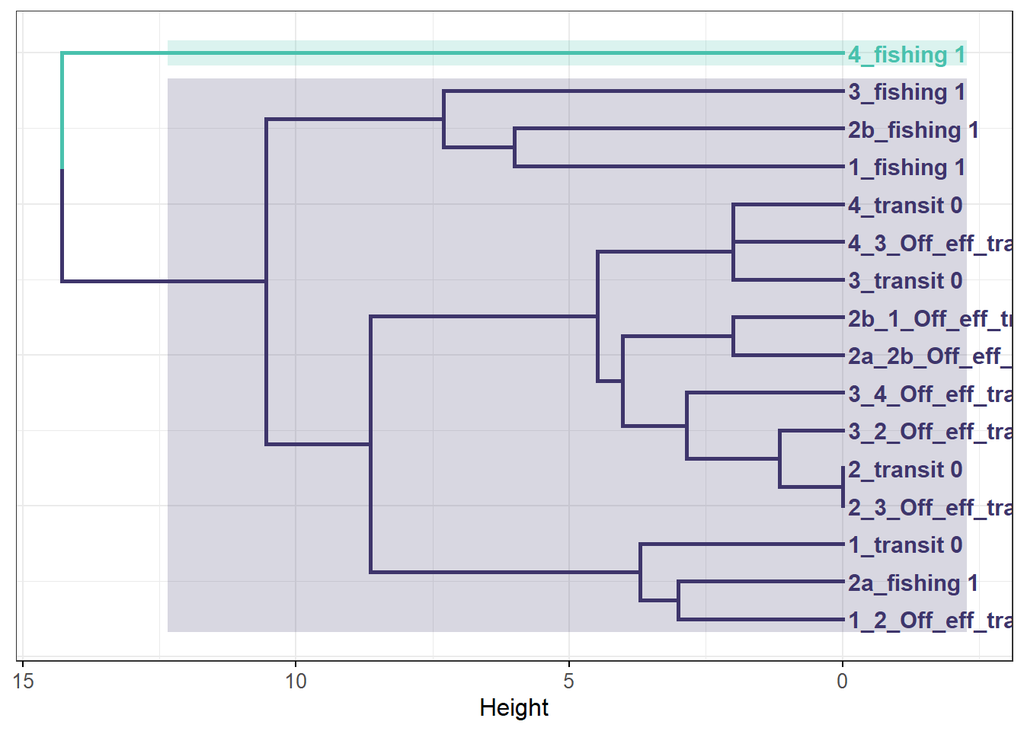

```r
# does vessel behavior differ by cluster membership?
# cluster ID = predictor
# vessel behav = response, coded as 1/0 (fishing/transit)

# add cluster labels to seq ID to associate w/fishing vs. transit
seq_clust_lab_tol63 <- selns_seq_wide_tol63 |>
  select(seq_ID) |>
  add_column(clust_ID = event_clust_tol63_cut)|>
  mutate(fish_state_binom = case_when(grepl("fishing", seq_ID)==TRUE ~ 1,
                   TRUE ~ 0),
         leaf_label = paste(seq_ID, fish_state_binom))

event_clusters_tol63$order.lab <- seq_clust_lab_tol63$leaf_label[event_clusters_tol63$order]
clust_colors = viridis::mako(n = 2, begin = 0.25, end = 0.75)

fviz_dend(event_clusters_tol63,
          k = 2,
          color_labels_by_k = TRUE,
          k_colors = clust_colors,
          labels_font = "bold",

          rect = TRUE,
          rect_border = clust_colors,
          rect_fill = TRUE,

          lwd=1,
          horiz = TRUE,
          ggtheme = theme_bw()) +
  theme(axis.text = element_text(size = 10),
        axis.title.x = element_text(size = 12),
        title = element_blank())
```

```r
ggsave("figs/dendrogram_k2_tol63.png", height=8, width=10, units = "in", dpi = 300)
```

Some observations from TOL63 dendrogram:

- fishing still outgroup in main cluster, but only one sequence actually got separated out

Fisher’s Exact Test to see if cluster membership associated with fishing

```r
# Fisher's Exact test to see if cluster assignment is related to fishing activity

fisher_tab_tol63 <- table(seq_clust_lab_tol63 |> ungroup() |> select(clust_ID, fish_state_binom))
fisher.test(fisher_tab_tol63)
```

```
##
##  Fisher's Exact Test for Count Data
##
## data:  fisher_tab_tol63
## p-value = 0.3125
## alternative hypothesis: true odds ratio is not equal to 1
## 95 percent confidence interval:
##  0.0564101       Inf
## sample estimates:
## odds ratio
##        Inf
```

## TOL125

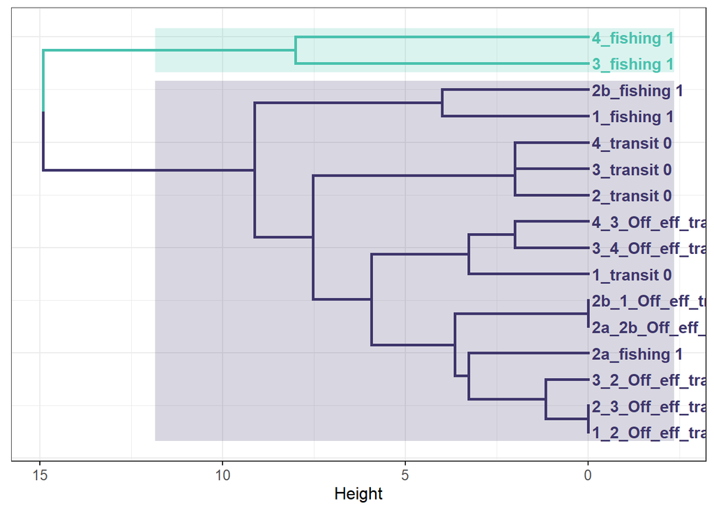

```r
# does vessel behavior differ by cluster membership?
# cluster ID = predictor
# vessel behav = response, coded as 1/0 (fishing/transit)

# add cluster labels to seq ID to associate w/fishing vs. transit
seq_clust_lab_tol125 <- selns_seq_wide_tol125 |>
  select(seq_ID) |>
  add_column(clust_ID = event_clust_tol125_cut)|>
  mutate(fish_state_binom = case_when(grepl("fishing", seq_ID)==TRUE ~ 1,
                   TRUE ~ 0),
         leaf_label = paste(seq_ID, fish_state_binom))

event_clusters_tol125$order.lab <- seq_clust_lab_tol125$leaf_label[event_clusters_tol125$order]
clust_colors = viridis::mako(n = 2, begin = 0.25, end = 0.75)

fviz_dend(event_clusters_tol125,
          k = 2,
          color_labels_by_k = TRUE,
          k_colors = clust_colors,
          labels_font = "bold",

          rect = TRUE,
          rect_border = clust_colors,
          rect_fill = TRUE,

          lwd=1,
          horiz = TRUE,
          ggtheme = theme_bw()) +
  theme(axis.text = element_text(size = 10),
        axis.title.x = element_text(size = 12),
        title = element_blank())
```

```r
ggsave("figs/dendrogram_k2_tol125.png", height=8, width=10, units = "in", dpi = 300)
```

Some observations from TOL125 dendrogram:

- captured line 3&4 as separate cluster; if k=3 would have 2 fishing clusters & one non-fishing cluster so still somewhat useful

Fisher’s Exact Test to see if cluster membership associated with fishing

```r
# Fisher's Exact test to see if cluster assignment is related to fishing activity

fisher_tab_tol125 <- table(seq_clust_lab_tol125 |> ungroup() |> select(clust_ID, fish_state_binom))
fisher.test(fisher_tab_tol125)
```

```
##
##  Fisher's Exact Test for Count Data
##
## data:  fisher_tab_tol125
## p-value = 0.08333
## alternative hypothesis: true odds ratio is not equal to 1
## 95 percent confidence interval:
##  0.452605      Inf
## sample estimates:
## odds ratio
##        Inf
```

## TOL2000

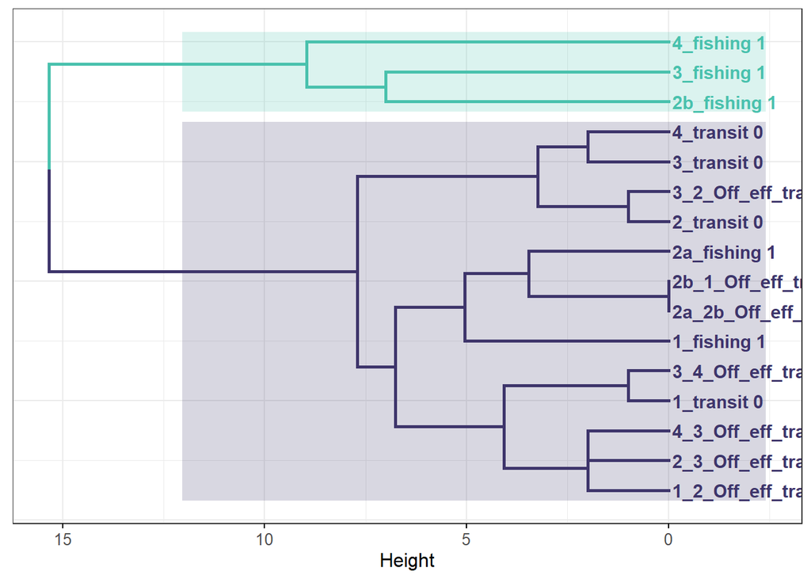

```r
# does vessel behavior differ by cluster membership?
# cluster ID = predictor
# vessel behav = response, coded as 1/0 (fishing/transit)

# add cluster labels to seq ID to associate w/fishing vs. transit
seq_clust_lab_tol2k <- selns_seq_wide_tol2k |>
  select(seq_ID) |>
  add_column(clust_ID = event_clust_tol2k_cut)|>
  mutate(fish_state_binom = case_when(grepl("fishing", seq_ID)==TRUE ~ 1,
                   TRUE ~ 0),
         leaf_label = paste(seq_ID, fish_state_binom))

event_clusters_tol2k$order.lab <- seq_clust_lab_tol2k$leaf_label[event_clusters_tol2k$order]
clust_colors = viridis::mako(n = 2, begin = 0.25, end = 0.75)

fviz_dend(event_clusters_tol2k,
          k = 2,
          color_labels_by_k = TRUE,
          k_colors = clust_colors,
          labels_font = "bold",

          rect = TRUE,
          rect_border = clust_colors,
          rect_fill = TRUE,

          lwd=1,
          horiz = TRUE,
          ggtheme = theme_bw()) +
  theme(axis.text = element_text(size = 10),
        axis.title.x = element_text(size = 12),
        title = element_blank())
```

```r
ggsave("figs/dendrogram_k2_tol2k.png", height=8, width=10, units = "in", dpi = 300)
```

Some observations from TOL2000 dendrogram:

- fishing from lines 1 and 2a clustered with off-effort maneuvering from those same lines but fishing lines 3, 4, and 2b were separated out (distance effect?)

Fisher’s Exact Test to see if cluster membership associated with fishing

```r
# Fisher's Exact test to see if cluster assignment is related to fishing activity

fisher_tab_tol2k <- table(seq_clust_lab_tol2k |> ungroup() |> select(clust_ID, fish_state_binom))
fisher.test(fisher_tab_tol2k)
```

```
##
##  Fisher's Exact Test for Count Data
##
## data:  fisher_tab_tol2k
## p-value = 0.01786
## alternative hypothesis: true odds ratio is not equal to 1
## 95 percent confidence interval:
##  1.1817    Inf
## sample estimates:
## odds ratio
##        Inf
```